# Отчёт по лабораторной работе №7

Расширенные настройки межсетевого экрана

Бызова Мария Олеговна

2025-10-14

# Цель работы

## Цель работы

Целью данной работы является получение навыков настройки межсетевого экрана в Linux в части переадресации портов и настройки Masquerading.

# Выполнение лабораторной работы

## Создание пользовательской службы firewalld

На виртуальной машине server войдём под нашим пользователем и откроем терминал. Далее перейдём в режим суперпользователя. На основе существующего файла описания службы ssh создадим файл с собственным описанием. Посмотрим содержимое файла службы (рис. 2).

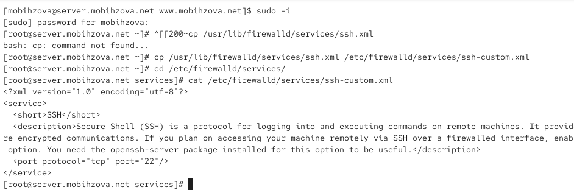

Рисунок 2: Переход в режим суперпользователя. Создание файла с собственным описанием на основе существующего файла описания службы ssh. Просмотр содержимого файла службы.

## Создание пользовательской службы firewalld

Откроем файл описания службы на редактирование и заменим порт 22 на новый порт (2022). В этом же файле скорректируем описание службы для демонстрации, что это модифицированный файл службы (рис. 3).

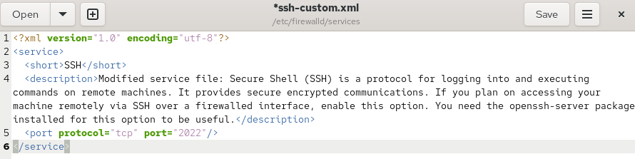

Рисунок 3: Открытие файла описания службы на редактирование и замена порта 22 на новый порт (2022).

## Создание пользовательской службы firewalld

Просмотрим список доступных FirewallD служб (рис. 4).

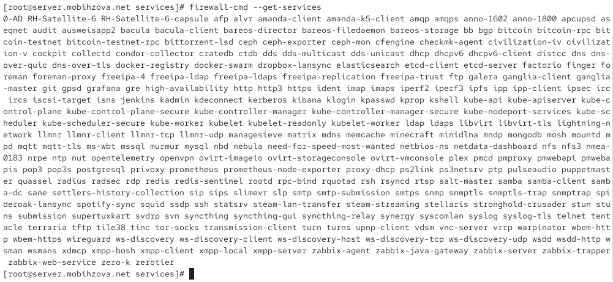

Рисунок 4: Просмотр списка доступных FirewallD служб.

## Создание пользовательской службы firewalld

Перегрузим правила межсетевого экрана с сохранением информации о состоянии и вновь выведем на экран список служб, а также список активных служб (рис. 5).

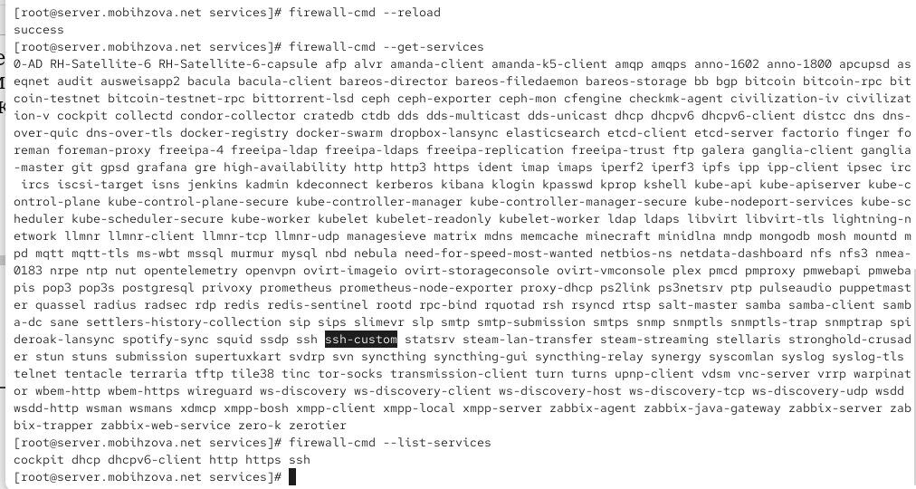

Рисунок 5: Перегрузка правил межсетевого экрана с сохранением информации о состоянии, вывод на экран списка служб, а также списка активных служб.

## Создание пользовательской службы firewalld

Добавим новую службу в FirewallD и выведем на экран список активных служб (рис. 6).

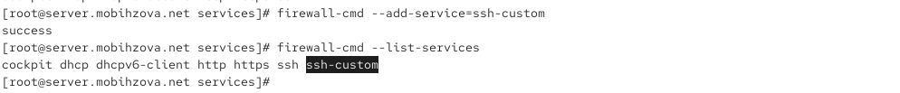

Рисунок 6: Добавление новой службы в FirewallD и вывод на экран списка активных служб.

## Создание пользовательской службы firewalld

Перегрузите правила межсетевого экрана с сохранением информации о состоянии (рис. 7).

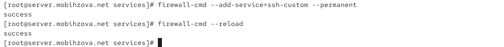

Рисунок 7: Перезагрузка правил межсетевого экрана с сохранением информации о состоянии

## Переадресация портов

Организуем на сервере переадресацию с порта 2022 на порт 22 (рис. 8).

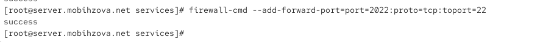

Рисунок 8: Организация переадресации на сервере с порта 2022 на порт 22.

## Переадресация портов

На клиенте попробуем получить доступ по SSH к серверу через порт 2022 (рис. 9).

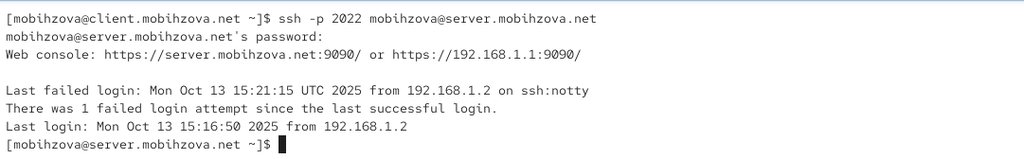

Рисунок 9: Попытка получить на клиенте доступ по SSH к серверу через порт 2022.

## Настройка Port Forwarding и Masquerading

На сервере посмотрим, активирована ли в ядре системы возможность перенаправления IPv4-пакетов (рис. 10).

## Настройка Port Forwarding и Masquerading

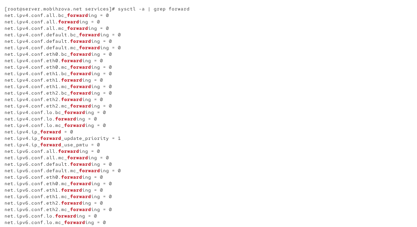

Рисунок 10: Просмотр на сервере, активирована ли в ядре системы возможность перенаправления IPv4-пакетов.

## Настройка Port Forwarding и Masquerading

Включим перенаправление IPv4-пакетов на сервере и маскарадинг на сервере (рис. 11).

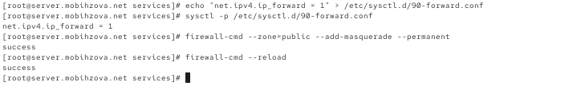

Рисунок 11: Включение перенаправления IPv4-пакетов на сервере и маскарадинга на сервере.

## Настройка Port Forwarding и Masquerading

На клиенте проверим доступность выхода в Интернет (рис. 12).

[figure not shown]

Рисунок 12: Проверка доступности выхода в Интернет на клиенте.

## Внесение изменений в настройки внутреннего окружения виртуальной машины

На виртуальной машине server перейдём в каталог для внесения изменений в настройки внутреннего окружения /vagrant/provision/server/, создадим в нём каталог firewall, в который поместим в соответствующие подкаталоги конфигурационные файлы FirewallD. Создадим в каталоге /vagrant/provision/server файл firewall.sh (рис. 13).

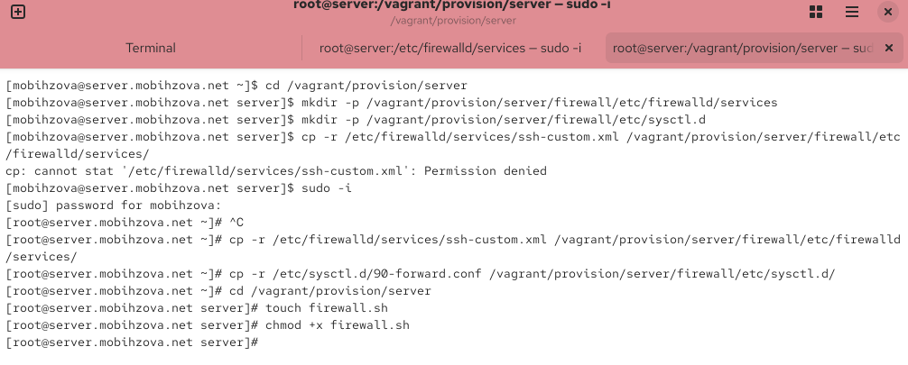

Рисунок 13: Открытие каталога для внесения изменений в настройки внутреннего окружения /vagrant/provision/server/, создание в нём каталога firewall.

## Внесение изменений в настройки внутреннего окружения виртуальной машины

Открыв его на редактирование, пропишем в нём скрипт из лабораторной работы (рис. 14).

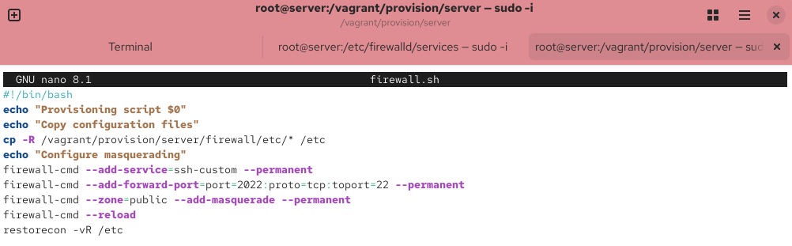

Рисунок 14: Открытие файла на редактирование и прописывание в нём скрипта из лабораторной работы.

## Внесение изменений в настройки внутреннего окружения виртуальной машины

Для отработки созданного скрипта во время загрузки виртуальной машины server в конфигурационном файле Vagrantfile добавим в разделе конфигурации для сервера соответствующую запись (рис. 15).

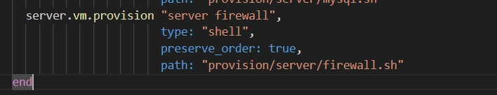

Рисунок 15: Добавление в раздел конфигурации для сервера соответсвуюущю запись в Vagrantfile

# Выводы

## Выводы

В ходе выполнения лабораторной работы были получены навыки настройки межсетевого экрана в Linux в части переадресации портов и настройки Masquerading.